# Chapter 9 Notes

Jack Nystrom

AP Chemistry

**Chapter 9 Notes**

Writing Lewis structures to model certain compounds’ bonding is simple and works great. But when we start to take into account the specific orbitals of each of a compound’s atoms, things can get to be more tricky. For example, in Methane (CH<sub>4</sub>), the hydrogens each have one 1s orbital, and the carbon has three 2p orbitals and one 2s orbital (remember: only the outer shell is considered for bonding). That seems to show that there will be two different types of C–H bonds, but from experiment we know there aren’t. As such, we can determine that carbon’s different orbitals mix to form four identical orbitals for bonding; called sp<sup>3</sup> orbitals.

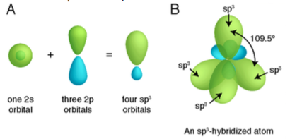

This is called **Hybridization**: The mixing of the native atomic orbitals to form special orbitals for bonding. In the case of carbon, we say that it is “sp<sup>3</sup> hybridized.”

*Whenever a set of equivalent tetrahedral atomic orbitals is required by an atom, this model assumes that the atom adopts a set of sp<sup>3</sup> orbitals; it is sp<sup>3</sup> hybridized.*

sp<sup>3</sup> isn’t the only form of hybridization. In Ethylene (C<sub>2</sub>H<sub>4</sub>), for example, each Carbon atom has two hydrogen atoms and one other carbon atom (double) bonded to it. This requires a trigonal planar arrangement (120 degree angles). Since carbon’s one 2s and three 2p orbitals do not fit that, we need a new set of hybrid orbitals. (somewhat arbitrarily) three sp<sup>2</sup> hybrid orbitals are used (and the remaining unused 2p orbital from carbon is left behind, oriented perpendicular to the trigonal plane).

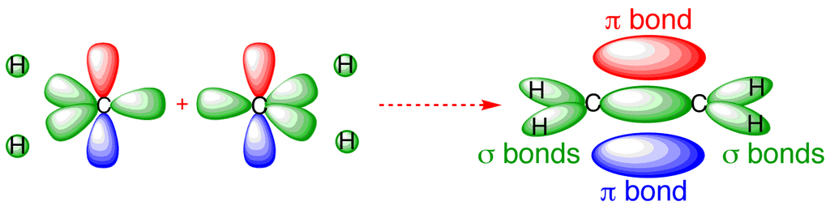

The bonds in ethylene can be described using those hybrid and non-hybrid orbitals. Each of the sp<sup>2</sup> orbitals is used to share electrons (with H and with the other C). Those electrons occupy the space in the very center between the two atoms, called a **Sigma Bond(σ)**. Additionally, electrons can occupy the space between the two “vertical” P orbitals on each C atom, called **Pi Bonds(π)**. In summary, Sigma bonds form from orbitals whose lobes point toward each other, and Pi bonds result from parallel orbitals. A double bond always consists of one sigma bond and one pi bond.

*Whenever an atom is surrounded by three effective pairs, A set of sp<sup>2</sup> hybrid orbitals is required.*

In a case like CO2—two effective pairs, both double bonds—we again need another hybrid orbital, as neither sp<sup>2</sup> nor sp<sup>3</sup> fit the characteristics of two pairs and linear at 180 degrees. To obtain this using carbon’s three 2p orbitals and one 2s orbital, we use two hybrid sp orbitals, leaving two 2p orbitals behind. The two sp orbitals form sigma bonds with one oxygen each, and the two leftover 2p orbitals form pi bonds with one oxygen each (double bond is always 1 sigma + 1 pi).

*Two effective pairs around an atom will always require sp hybridization of that atom.*

To account for atoms that don’t obey the quartet rule in a molecule (>4 bonds/effective pairs), like PCl<sub>5</sub>, we use dsp<sup>3</sup> hybridization: one d orbital, one s orbital and three p orbitals. For 6 effective pairs, like in SF<sub>6</sub>, we use d<sup>2</sup>sp<sup>3</sup> hybridization. Since each of the Cl’s in PCl<sub>5</sub> and each of the F’s in SF<sub>6</sub> all have 4 effective pairs (one bond + 3 lone electron pairs), they are assumed to use sp<sup>3</sup> hybridization.

**Molecular Orbital Model**: Another model used to describe bonding that has advantages over the localized electron model.

Just as atomic orbitals are solutions to the quantum mechanical treatment of atoms, **molecular orbitals (MOs)** are solutions to the molecular problem.

When analyzing H<sub>2</sub> using this model, solving its quantum mechanical equations results in two molecular orbits, MO<sub>1</sub> and MO<sub>2</sub>. MO<sub>1</sub> = 1s<sub>A</sub> + 1s<sub>B</sub>, and MO<sub>2</sub> = 1s<sub>A</sub> - 1s<sub>B</sub> (1s<sub>A</sub> and 1s<sub>B</sub> are the two 1s orbitals on each H, from the localized electron model)

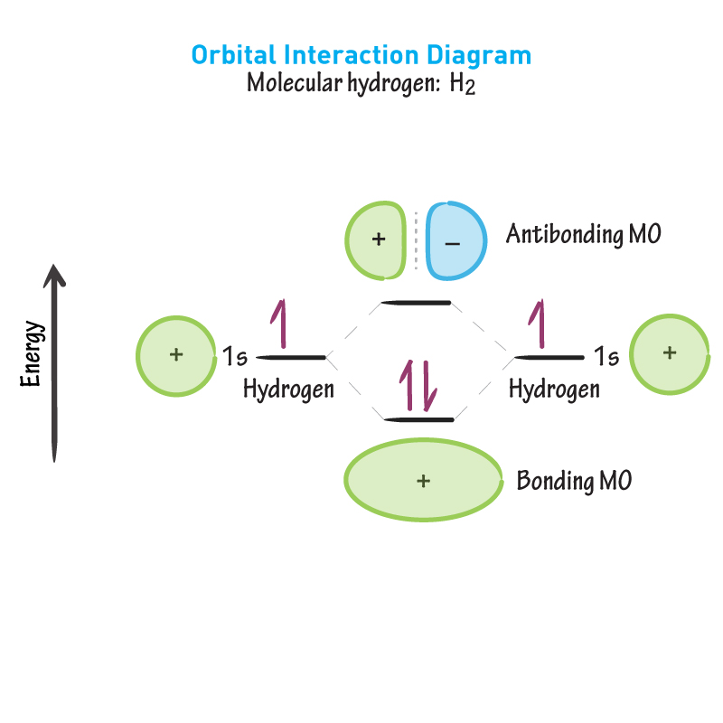

For H<sub>2</sub>, the electron probability of both molecular orbitals is centered on the line through the two nuclei; as such, they are called **Sigma Molecular Orbitals**.

The molecular orbitals of a compound replace the atomic orbitals of its individual atoms.

A **bonding molecular orbital** is lower in energy than the atomic orbitals that make it up.

An **antibonding molecular orbital** is higher in energy than the atomic orbitals that make it up.

The labels on molecular orbitals indicate their symmetry (shape), the parent atomic orbitals, and whether they’re bonding or antibonding. * = antibonding. In the case of H<sub>2</sub>, both MO’s have sigma symmetry (electron probability between nuclei), and both are constructed from 1s atomic orbitals. So the MO’s are labeled as MO<sub>1</sub> = σ<sub>1s</sub> and MO<sub>2</sub> = σ<sub>1s</sub>* .

Molecular electron configurations are written in the same way as for atomic orbitals. Since both electrons occupy the lower energy bonding molecular orbital, σ<sub>1s</sub>, it is written as σ<sub>1s</sub><sup>2</sup> .

The number of molecular orbitals will always be the same as the number of atomic orbitals used to construct them.

**Bond order**: a concept used to indicate bond strength. (larger value = greater bond strength)

Bond order = (# of bonding e<sup>-</sup> - # of antibonding e<sup>-</sup>) / 2

In H<sub>2</sub>, the bond order is (2 - 0)/2 = 1. In H<sub>2</sub><sup>-</sup>, with 3 electrons, the bond order is (2 - 1)/2 = ½.

To participate in molecular orbitals, atomic orbitals must overlap in space. (Valence orbitals only)

To illustrate the difference between constructive and destructive interference between MOs:

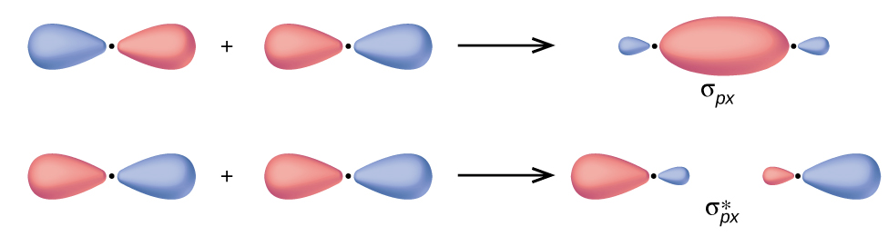

Electron probability that lies above and/or below the line between the nuclei => **Pi Molecular Orbitals**.

**Paramagnetism** causes a substance to be attracted into an including magnetic field.

**Diamagnetism** causes a substance to be repelled from an including magnetic field.

*Paramagnetism is associated with unpaired electrons and diamagnetism is associated with paired electrons.*

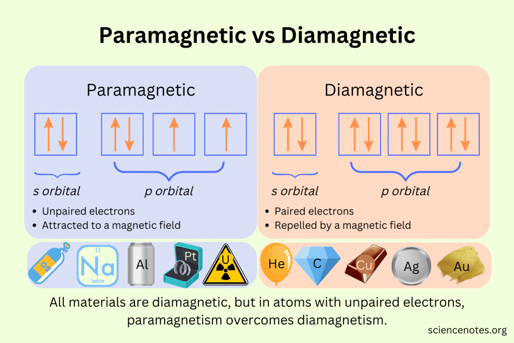

While there are correlations between the bond order, bond length and bond energy within the molecular orbital model, it does not give us exact values (eg. two different bond order 1 bonds can still be very different energy).

Since every double bond has one sigma and one pi bond (and every bonder order higher has one sigma bond), we can assume that the non-localization of orbitals is really only specific to pi bonds—the sigma bonds are localized but the pi bonds are not. This is useful for drawing better orbital diagrams; it essentially allows us to combine the Localized Electron Model and the Molecular Orbital Model.

Consider C<sub>6</sub>H<sub>6</sub> , which has 6 carbons each bonded with one sigma bond, and where every other bond also has a pi bond (via the leftover p orbitals perpendicular to the molecule’s plane).

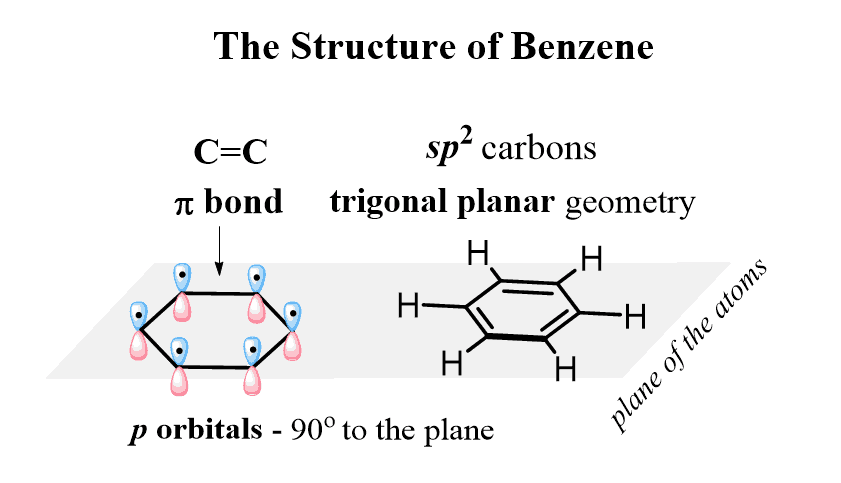

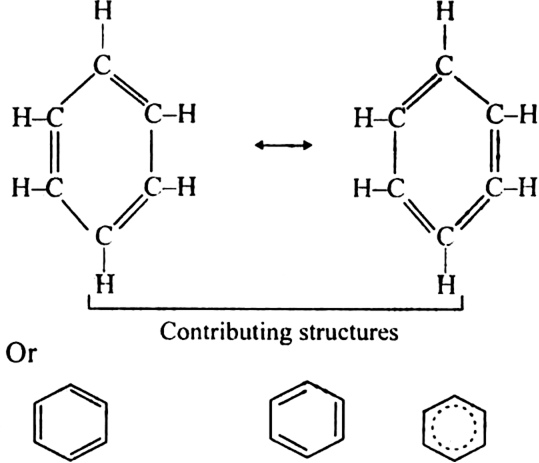

IMPORTANT: For drawing MO diagrams, always start with this type of diagram:

[figure not shown]